# Additional excercises: Part 2 and Part 3 - answered

# Simple functions

Write a function `to_the_power` that will take a numerical vector and return a vector with each element taken to the power of it’s index.

```r
to_the_power <- function(vec) {
  vec ^ (1:length(vec))
}

# check
to_the_power(1:3) == c(1, 4, 27)
```

Write a function `moving_average`. It should return an average of elements in the vector until, and including, an element at that position.

```r
moving_average <- function(vec) {
  cumsum(vec) / 1:length(vec)
}

# check
moving_average(1:5) == c(1, 1.5, 2, 2.5, 3)
```

Write a function `non_na` that will take a vector and return only non NA elements.

```r
non_na <- function(vec) {
  vec[!is.na(vec)]
}

# check
non_na(c(NA, 1:3, NA, 4:6, NA)) == 1:6
```

Write a function `get_summary` that will take a vector and return the summary statistics: median, min, max, 25% and 75% percentiles.

```r
get_summary <- function(vec) {
  median_ = median(vec)
  min_ = min(vec)
  max_ = max(vec)
  perc25_ = quantile(vec, 0.25)
  perc75_ = quantile(vec, 0.75)

  # return
  c(median_, min_, max_, perc25_, perc75_)
}

# check
get_summary(1:10) == c(5.5, 1, 10, 3.25, 7.75)
```

# Flow

You have an urn with balls from 1 to 100. You want to find out how often you need to draw a ball to get number 55. This is an experiment with replacement – you put the ball back each time you draw. Simulate 1000 runs of the experiment to get an accurate estimation of the required draws.

Use seed 7 to make the experiment reproducible. Use loops (for, while) for the solution.

```r
set.seed(7)
success <- 0
for (i in 1000) {
  ball <- sample(1, 1:100)
  success = success + (ball == 55)
}
print(paste0("The probability is equal to ", succes / 1000))
```

What fraction of tosses of a well-balanced (in 1000) conists of tails?

```r
tails <- 0
for (i in 1:1000) {
  tails = tails + sample(c(0,1), 1)
}
print(paste0("Tails consist of ", tails / 1000,
             " of all toses."))
```

```
[1] "Tails consist of 0.487 of all toses."
```

Now do above 1000 times and save results to a vector - `tails_MC`.

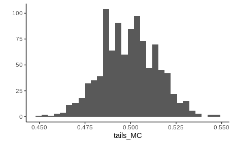

Find the smallest number between 10000 and 20000 that is divisible by 1234.

```r
for (n in 10000:20000) {
  if (n %% 1234 == 0) {
    print(paste0("Found it! ", n))
    break
  }
}
```

```
[1] "Found it! 11106"
```

Find the largest number between 10000 and 20000 that is divisible by 1234.

```r
for (n in 20000:10000) {
  if (n %% 1234 == 0) {
    print(paste0("Found it! ", n))
    break
  }
}
```

```
[1] "Found it! 19744"
```

# More complex functions

Create a function `is_angram` that given two strings (one word each), check if one is an anagram of another. I.e.

```r
is_anagram <- function(word1, word2) {
  word1_ <- strsplit(word1, "")[[1]]
  word2_ <- strsplit(word2, "")[[1]]
  all(word1_ %in% word2_) |
    all(word2_ %in% word1_)
}
# check
is_anagram("option", "potion")
```

```
[1] TRUE
```

Write the function `map_to_numbers` that given a character string will return it’s representation as vector with positions of the letters in alphabet.

```r
map_to_numbers <- function(word) {
  word_ <- strsplit(word, "")[[1]]
  reverse_letters <- 1:length(letters)
  names(reverse_letters) <- letters
  reverse_letters[word_]
}
# check
map_to_numbers("abc")
```

```
a b c
1 2 3
```

```r
map_to_numbers("onomatopeja")
```

```
 o  n  o  m  a  t  o  p  e  j  a
15 14 15 13  1 20 15 16  5 10  1
```